# Решеточные газы и решеточное уравнение Больцмана

Этап №1

Ромицына Анастасия

Российский университет дружбы народов

2 марта 2026

# Информация

## Докладчики

- Ромицына Анастасия Романовна
- Спелов Андрей Николаевич
- Исупов Олег
- Ко Антон

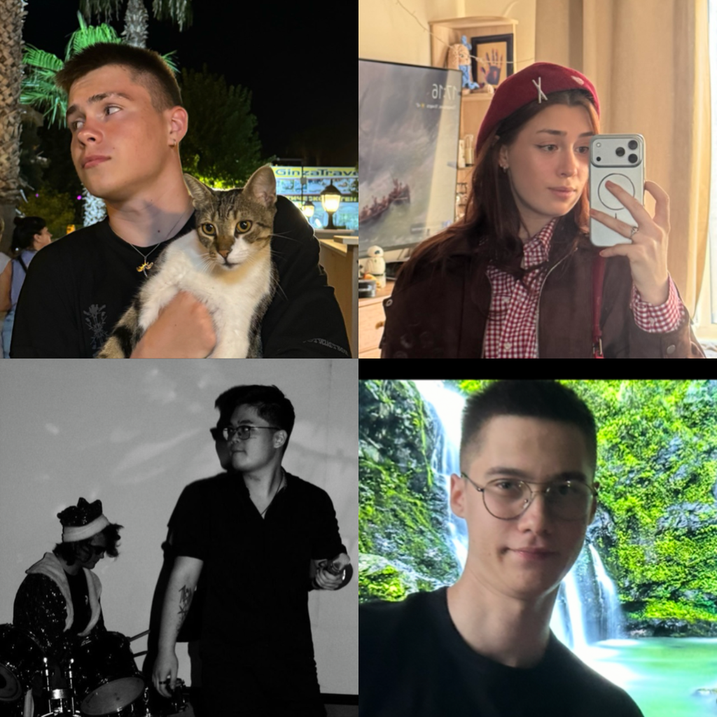

# Вводная часть

## Цели проекта

- Изучить методы решеточных газов (LGA) и решеточного уравнения Больцмана (LBE) для моделирования гидродинамических течений.

## Задачи проекта

- Изучить теоретические основы метода LGA.
- Понять переход от дискретной модели LGA к континуальному решеточному уравнению Больцмана (LBE).
- Рассмотреть математическую формулировку LBE с BGK-приближением (модель с одним временем релаксации).
- Определить способ перехода от микроскопических функций распределения к макроскопическим параметрам течения (плотность, скорость).

## Определение

Пространство: Дискретная решетка (например, квадратная или треугольная). Время: Дискретные шаги (Δt = 1). Частицы: Точечные, единичной массы. Могут двигаться только по связям решетки с фиксированной скоростью. Принцип исключения: В узле не может быть двух частиц с одинаковым направлением скорости.

Эволюция системы происходит в два этапа:

Распространение (Streaming): Каждая частица перелетает в соседний узел в направлении своей скорости. Столкновение (Collision): Частицы, прилетевшие в один узел, сталкиваются. Правила столкновений подбираются так, чтобы сохранялись масса и импульс.

## От микро- к макро- моделированию

Моделирование течений жидкости и газа — сложная вычислительная задача.

Подходы: Макроскопический: Уравнения Навье-Стокса (решаются численно, но требуют допущений). Микроскопический: Молекулярная динамика (слишком ресурсоемко для макроскопических задач). Идея: Можно ли создать модель, которая, обладая простотой микроскопического подхода, автоматически воспроизводила бы правильное макроскопическое поведение жидкости? Ответ: Да, это методы решеточных газов (LGA) и решеточного уравнения Больцмана (LBE).

## Основная часть

Решетка: Квадратная. Скорости: 4 направления (вверх, вниз, влево, вправо). Правила столкновений (самые простые):

Конфигурация “лоб в лоб” (частицы направлены навстречу друг другу) → поворот на 90°. Все остальные конфигурации → частицы пролетают без взаимодействия. Недостаток: Модель HPP не обладает достаточной симметрией для правильного описания уравнений Навье-Стокса.

## Переход к решеточному уравнению Больцмана (LBE)

Чтобы избавиться от шума, переходят от дискретных частиц к вероятностному описанию. Вместо наличия или отсутствия частицы (0 или 1) вводится одночастичная функция распределения f_k(x, t). f_k — это вероятность найти частицу в узле x в момент времени t, движущуюся со скоростью c_k. Или, что то же самое, среднее число таких частиц.

Усредненная по ансамблю или по времени динамика LGA приводит к решеточному уравнению Больцмана (LBE):

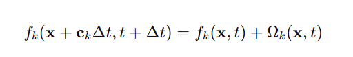

Слева: Распространение (streaming). Справа: Оператор столкновений (collision).

## Модель BGK (Бхатнагар-Гросс-Крук)

Самый популярный и простой вид оператора столкновений — BGK-приближение (модель с одним временем релаксации).

где: t — время релаксации (безразмерный параметр). f_k^{eq} — локально-равновесная функция распределения. Преимущество: Простота и физическая обоснованность.

## Макроскопические параметры

Макроскопические величины (плотность ρ и скорость u) в узле получаются из моментов функций распределения:

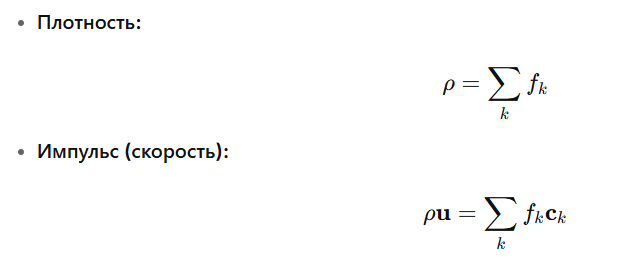

# Заключительная часть

## Выводы по первому этапу

На данном этапе мы рассмотрели теоретические основы методов моделирования гидродинамики на решетках:

Решеточные газы (LGA) — дискретные модели частиц с простыми правилами столкновений. Они наглядно демонстрируют физику процесса, но подвержены статистическому шуму. Решеточное уравнение Больцмана (LBE) является эволюционным уравнением для функций распределения, которое получается из LGA путем усреднения. Модель BGK (с одним временем релаксации) — это эффективный и широко используемый способ описания столкновительного члена в LBE. Макроскопические параметры (плотность, скорость) вычисляются как моменты функций распределения f_k. Эти методы позволяют эффективно моделировать широкий класс гидродинамических течений.

## Источники

- Моделирование физических процессов и явлений на ПК / Д. А. Медведев, А. Л. Куперштох, Э. Р. Прууэл [и др.]. – Новосибирск : Новосиб. гос. ун-т, 2010. – 101 с. – ISBN 978-5-94356-933-3.